# ECON6027_1b

Dr. Liu

2024-08-22

## Install sf

If you are installing sf (or any other package for the first time, use the command “install.packages(‘sf’, dep=T)” or the “Install” button on the side panel.

Troubleshooting and more info: https://r-spatial.github.io/sf/

```r
is.element('sf', installed.packages())
```

```
## [1] TRUE
```

```r
library(sf)
```

At the time of updating my codes, the most recent version of GEOS, GDAL, and PROJ are: GEOS 3.12.2, GDAL 3.9.1, PROJ 9.4.1

## Read a shapefile to R

Remember to change the working directory first. The command below reads a MULTIPOLYGON simple feature collection with 323 features and 15 fields

```r
sg_pa = st_read("MP14_SUBZONE_WEB_PL.shp")
```

## Inspect the shapefile

```r
class(sg_pa)
```

```
## [1] "sf"         "data.frame"
```

```r
summary(sg_pa)
```

```
##     OBJECTID       SUBZONE_NO      SUBZONE_N          SUBZONE_C
##  Min.   :  1.0   Min.   : 1.000   Length:323         Length:323
##  1st Qu.: 81.5   1st Qu.: 2.000   Class :character   Class :character
##  Median :162.0   Median : 4.000   Mode  :character   Mode  :character
##  Mean   :162.0   Mean   : 4.625
##  3rd Qu.:242.5   3rd Qu.: 6.500
##  Max.   :323.0   Max.   :17.000
##     CA_IND           PLN_AREA_N         PLN_AREA_C          REGION_N
##  Length:323         Length:323         Length:323         Length:323
##  Class :character   Class :character   Class :character   Class :character
##  Mode  :character   Mode  :character   Mode  :character   Mode  :character
##
##
##
##    REGION_C           INC_CRC            FMEL_UPD_D             X_ADDR
##  Length:323         Length:323         Min.   :2014-12-05   Min.   : 5093
##  Class :character   Class :character   1st Qu.:2014-12-05   1st Qu.:21864
##  Mode  :character   Mode  :character   Median :2014-12-05   Median :28465
##                                        Mean   :2014-12-05   Mean   :27257
##                                        3rd Qu.:2014-12-05   3rd Qu.:31674
##                                        Max.   :2014-12-05   Max.   :50425
##      Y_ADDR        SHAPE_Leng        SHAPE_Area                geometry
##  Min.   :19579   Min.   :  871.5   Min.   :   39438   MULTIPOLYGON :323
##  1st Qu.:31776   1st Qu.: 3709.6   1st Qu.:  628261   epsg:NA      :  0
##  Median :35113   Median : 5211.9   Median : 1229894   +proj=tmer...:  0
##  Mean   :36106   Mean   : 6524.4   Mean   : 2420882
##  3rd Qu.:39869   3rd Qu.: 6942.6   3rd Qu.: 2106483
##  Max.   :49553   Max.   :68083.9   Max.   :69748299
```

```r
head(sg_pa)
```

```
## Simple feature collection with 6 features and 15 fields
## Geometry type: MULTIPOLYGON
## Dimension:     XY
## Bounding box:  xmin: 24468.89 ymin: 28369.47 xmax: 32362.39 ymax: 30542.74
## Projected CRS: SVY21
##   OBJECTID SUBZONE_NO      SUBZONE_N SUBZONE_C CA_IND      PLN_AREA_N
## 1        1          1   MARINA SOUTH    MSSZ01      Y    MARINA SOUTH
## 2        2          1   PEARL'S HILL    OTSZ01      Y          OUTRAM
## 3        3          3      BOAT QUAY    SRSZ03      Y SINGAPORE RIVER
## 4        4          8 HENDERSON HILL    BMSZ08      N     BUKIT MERAH
## 5        5          3        REDHILL    BMSZ03      N     BUKIT MERAH
## 6        6          7 ALEXANDRA HILL    BMSZ07      N     BUKIT MERAH
##   PLN_AREA_C       REGION_N REGION_C          INC_CRC FMEL_UPD_D   X_ADDR
## 1         MS CENTRAL REGION       CR 5ED7EB253F99252E 2014-12-05 31595.84
## 2         OT CENTRAL REGION       CR 8C7149B9EB32EEFC 2014-12-05 28679.06
## 3         SR CENTRAL REGION       CR C35FEFF02B13E0E5 2014-12-05 29654.96
## 4         BM CENTRAL REGION       CR 3775D82C5DDBEFBD 2014-12-05 26782.83
## 5         BM CENTRAL REGION       CR 85D9ABEF0A40678F 2014-12-05 26201.96
## 6         BM CENTRAL REGION       CR 9D286521EF5E3B59 2014-12-05 25358.82
##     Y_ADDR SHAPE_Leng SHAPE_Area                       geometry
## 1 29220.19   5267.381  1630379.3 MULTIPOLYGON (((31495.56 30...
## 2 29782.05   3506.107   559816.2 MULTIPOLYGON (((29092.28 30...
## 3 29974.66   1740.926   160807.5 MULTIPOLYGON (((29932.33 29...
## 4 29933.77   3313.625   595428.9 MULTIPOLYGON (((27131.28 30...
## 5 30005.70   2825.594   387429.4 MULTIPOLYGON (((26451.03 30...
## 6 29991.38   4428.913  1030378.8 MULTIPOLYGON (((25899.7 297...
```

```r
table(st_is_valid(sg_pa))
```

```
##
## FALSE  TRUE
##     9   314
```

There are 9 false entries. As a habit you should always check the validity especially if the dataset is downloaded from the Internet.

If there are FALSE entries, use the command st_make_valid() to validate the object.

```r
sg_pa = st_make_valid(sg_pa)
table(st_is_valid(sg_pa))
```

```
##
## TRUE
##  323
```

No more invalid entries!

## Visualise the shapefile

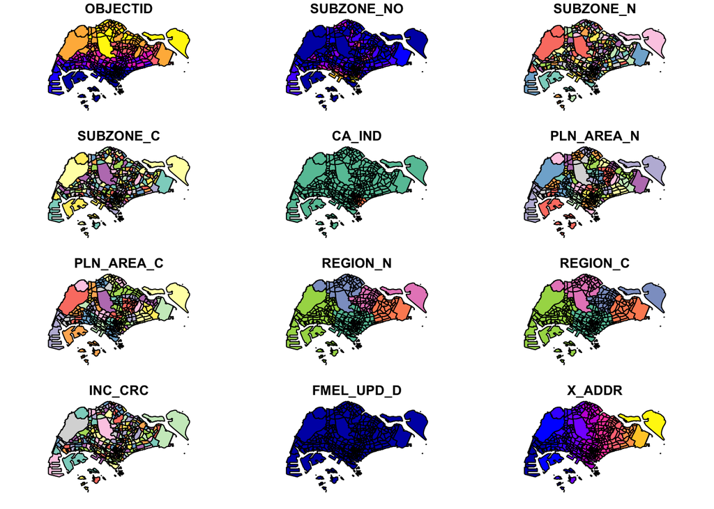

```r
plot(sg_pa, max.plot = 12)
```

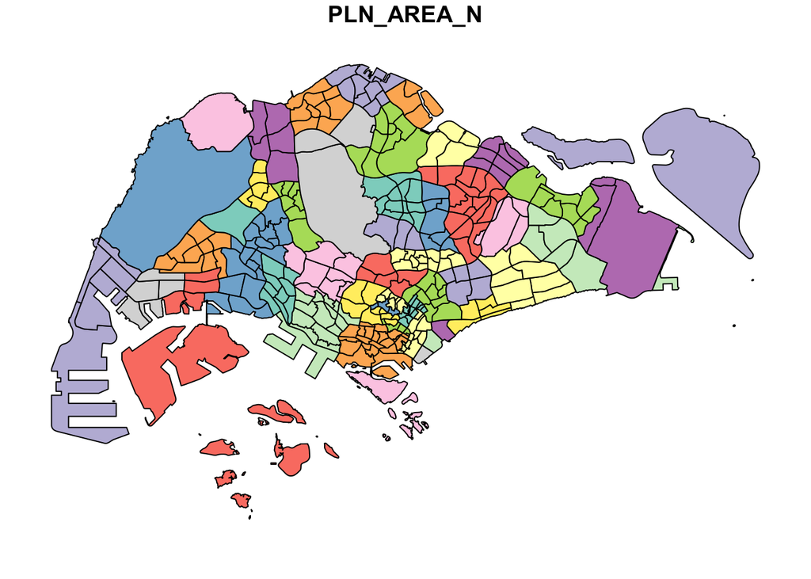

```r
plot(sg_pa["PLN_AREA_N"])
```

## Save an sf object to the hard drive

In the st_write() function, you can use the “dsn” (data source name) argument to specify which driver or the file format you need. For example “xxx.shp” will write the sf object to a shapefile as demonstrated below.

```r
st_write(sg_pa, "MySingapura.shp", delete_layer=T)
```

```
## Deleting layer `MySingapura' using driver `ESRI Shapefile'
## Writing layer `MySingapura' to data source
##   `MySingapura.shp' using driver `ESRI Shapefile'
## Writing 323 features with 15 fields and geometry type Unknown (any).
```

The “delete_layer = TRUE” argument will overwrite any other file of the same name.

If instead you want to save as a geojson file, use the following command.

```r
#st_write(sg_pa, "MySingapura.geojson")
```